# Data cleaning - Thesis

A. Schmidt

January 2, 2019

# Introduction

This code downloads and cleans the data I am using in my master thesis.

## Downloading packages

If mirror 10 (“UFRJ”) is offline, try changing `ind = 10` to `ind = 1`. Do the same thing if you get an error installing the `BETS` package.

```r
chooseCRANmirror(graphics = FALSE, ind = 10)
if (!require("pacman")) install.packages("pacman")
pacman::p_load(devtools, ggplot2, forecast, BETS, seasonal, seasonalview, lubridate, zoo, stargazer, gridExtra, reshape2, ggfortify, RColorBrewer, scales, quantmod, PerformanceAnalytics, strucchange, knitr, grid, ggpubr, gdata, vars, urca, compiler, DescTools, kableExtra, readxl)
```

# Data handling

## Downloading data

Last update: January 2, 2019.

All data was obtained from Brazil’s Central Bank repository (Sistema Gerenciador de Séries do Banco Central - SGS), except for the population estimate (used to compute per capita GDP). The following series were used (obs: beginning and end of the series corresponds to the available data, not actual data used in the work and some data were manipulated, for example interest rate were converted to annual - mannipulations are described in code and in the paper appendix):

- **Receitas tributárias - Regime de competência - Imposto de renda - Retido na fonte - Rendimento do trabalho** (*Labor Income*)
  - **Beginning of the series:** January, 1992.
  - **End of the series:** October, 2018.
  - **Unity:** u.m.c. milhões.
  - **Series number in SGS:** 7620.
  - **Source:** Brazil’s Central Bank - Statistics Department (BCB-DSTAT).
- **Receitas tributárias - Regime de competência - Imposto de renda - Retido na fonte - Rendimento do capital** (*Capital Income*)
  - **Beginning of the series:** January, 1992.
  - **End of the series:** October, 2018.
  - **Unity:** u.m.c. milhões.
  - **Series number in SGS:** 7621.
  - **Source:** Brazil’s Central Bank - Statistics Department (BCB-DSTAT).
- **Taxa de Juros - Selic** (*Interest Rate*)
  - **Beginning of the series:** July, 1986.
  - **End of the series:** December, 2018.
  - **Unity:** % monthly.
  - **Series number in SGS:** 4390.
  - **Source:** Brazil’s Central Bank - Open Market Operations Department (BCB-Demab).
- **Taxa referencial de swaps DI pré-fixada (BM&F) - Prazo de 90 dias (fim de período)** (*3-month treasury bill rate*)
  - **Beginning of the series:** September, 1999.
  - **End of the series:** November, 2018.
  - **Unity:** % annual.
  - **Series number in SGS:** 7818.
  - **Source:** BM&FBOVESPA S.A. - Bolsa de Valores, Mercadorias e Futuros (BM&FBOVESPA).
- **Índice nacional de preços ao consumidor-amplo (IPCA)** (*Price index*)
  - **Beginning of the series:** January, 1980.
  - **End of the series:** November, 2018.
  - **Unity:** Percent monthly variation.
  - **Series number in SGS:** 433
  - **Source:** Brazilian Institute of Geography and Statistics (IBGE).
- **Monthly GDP**
  - **Beginning of the series:** January, 1990.
  - **End of the series:** October, 2018.
  - **Unity:** Brazilian Real (R$) - millions.
  - **Series number in SGS:** 4380
  - **Source:** Brazil’s Central Bank - Economic Department (BCB-Depec).
- **Exchange Rate - USD Dollar (sell) - End of Period - Monthly** - OLD, I’m not using anymore
  - **Beginning of the series:** January, 1953.
  - **End of the series:** December, 2018.
  - **Unity:** u.m.c./US$.
  - **Series number in SGS:** 3696.
  - **Source:** Brazil’s Central Bank - Sisbacen PTAX800.
- **Real Effective Exchange Rate Index - Monthly**
  - **Beginning of the series:** January, 1988.
  - **End of the series:** OCtober, 2018.
  - **Unity:** Index (100 = Jun/1994).
  - **Series number in SGS:** 11752
  - **Source:** Brazil’s Central Bank - Economic Department (BCB-Depec).
- **Population estimate - monthly**
  - **Beginning of the series:** 01 January, 2000.
  - **End of the series:** 01 December, 2030.
  - **Unity:** People.
  - **Available where?** https://www.ibge.gov.br/estatisticas-novoportal/sociais/populacao/9109-projecao-da-populacao.html?edicao=9116&t=resultados
  - **Source:** Brazilian Institute of Geography and Statistics (IBGE).
- - **Population estimate - yearly**
  - **Beginning of the series:** 1980.
  - **End of the series:** 2050.
  - **Unity:** People.
  - **Available where?** https://www.ibge.gov.br/estatisticas-novoportal/sociais/populacao/9109-projecao-da-populacao.html?edicao=17996&t=resultados (the 2000’s review)
  - **Source:** Brazilian Institute of Geography and Statistics (IBGE).
  - **Obs:** I used this data to complete the monthly series. Since I’m using all data before 2000’s as prior, this is not a big issue.

## Downloading the data

```r
# Auxiliary variables, so I don't need to bother when something changes
inicio <- "1996-01-01"
fim    <- "2018-10-01"
inicio_deflator <- "1993-12-31"
inicio_swap     <- "1999-09-01"

# Don't mess with this code
inicio_cambio <- paste(seq(as.Date(inicio), length = 2, by = "-1 month")[2]) # 1 month before the beginning of the other series
inicio_ipca2   <- paste(seq(as.Date(inicio), length = 12, by = "-1 month")[12]) # 12 months before the beginning of the other series
inicio_pib2   <- paste(seq(as.Date(inicio), length = 12, by = "-1 year")[2]) # dunno
fim_ipca      <- paste(seq(as.Date(fim), length = 2, by = "1 month")[2]) # 1 month after the end of the other series
inicio_swap2 <- paste(seq(as.Date(inicio_swap), length = 2, by = "-1 month")[2]) # 1 1 month before the beginning of the other series

## Obs: In case you have a SQL problem, rollback this two packages and mannually download BETS from CRAN and reinstall it as well
## See: https://stackoverflow.com/questions/43073782/rmysql-system-error-10060 and https://github.com/pedrocostaferreira/BETS/issues/29
# require(devtools)
# install_version("DBI", version = "0.5", repos = "http://cran.us.r-project.org")
# install_version("RMySQL", version = "0.10.9", repos = "http://cran.us.r-project.org")

################################
##### Capital labor ratio ######
################################

trabalho <- BETS.get("7620", from = inicio, to = fim)
capital  <- BETS.get("7621", from = inicio, to = fim)
capital_trabalho <- capital/trabalho

########################
##### Price Index ######
########################

ipca_raw <- BETS.get("433", from = inicio_deflator, to = fim_ipca)
ipca2 <- ipca_raw
ipca2[1] <- 100

# The following calculation was made following IPEA methodology: http://www.ipeadata.gov.br/iframe_transformacao.aspx?width=1474&height=701
# Transforms in index
for (i in 2:length(ipca2)){
  ipca2[i] <- round(ipca2[(i-1)]*(1+ipca2[(i)]/100),2)
}

# Geometric Average
for (i in 1:(length(ipca2)-1)){
  ipca2[i] <- sqrt(ipca2[i]*ipca2[(i+1)])
}

# Change base to mar/2018
for (i in 1:length(ipca2)) {
  ipca2[i] <- tail(ipca2, n=2)[1]/ipca2[i]
}

# Elimitates data outside the period we are studying
ipca2 <- ts(ipca2,  start = c(1993, 12, 31), frequency = 12)
ipca_raw <- ts(ipca_raw,  start = c(1993, 12, 31), frequency = 12)
ano_ipca <- as.numeric(substr(inicio_cambio, start = 1, stop = 4))
mes_ipca <- as.numeric(substr(inicio_cambio, start = 6, stop = 7))
ano_ipca2 <- as.numeric(substr(inicio_pib2, start = 1, stop = 4))
mes_ipca2 <- as.numeric(substr(inicio_pib2, start = 6, stop = 7))
ipca3 <- window(ipca2, c(ano_ipca2, mes_ipca2))
ipca3 <- head(ipca3, n=length(ipca3)-1)
ipca2 <- window(ipca2, c(ano_ipca, mes_ipca))
ano_ipca <- as.numeric(substr(inicio_ipca2, start = 1, stop = 4))
mes_ipca <- as.numeric(substr(inicio_ipca2, start = 6, stop = 7))
ipca_raw <- window(ipca_raw, c(ano_ipca, mes_ipca))

# Removes last observation
ipca_raw <- ipca_raw[1:(length(ipca_raw)-1)]

ipca_acum <- ipca_raw/100 + 1
ipca <- vector()

final <- length(ipca_acum)
for (i in 12:final){
  ipca[(i-11)] <- (prod(ipca_acum[(i-11):i])-1)*100
}

ano <- as.numeric(substr(inicio, start = 1, stop = 4))
mes <- as.numeric(substr(inicio, start = 6, stop = 7))
dia <- as.numeric(substr(inicio, start = 9, stop = 10))

ipca <- ts(ipca,  start = c(ano, mes, dia), frequency = 12) # Date format YYYY MM DD

#############################
###### POPULATION ###########
#############################

pop2 <- data.frame(read_xlsx("D:\\Onedrive - Aisha\\OneDrive\\Documentos\\Mestrado Economia\\Dissertação\\Modelo final\\População Mensal Brasil.xlsx"))
pop <- pop2[13:nrow(pop2),]

################
##### GDP ######
################
PIBmensal <- BETS.get("4380", from = inicio_cambio, to = fim)
PIBmensal <- PIBmensal * ipca2

# Now the GDP to compute the annual variation
PIBmensal2 <- BETS.get("4380", from = inicio_pib2, to = fim)
PIBmensal2 <- PIBmensal2 * ipca3
## Creating a new series with lagged variables
# @#$&%@*#@%$@ piece of code is not working just dividing the variable, I'm going to use a for loop
# Had to create a new variable because I couldn't make it work.
PIBmensal_aux <- PIBmensal[-1]

PIBmensal_an <- vector()
for (i in 1:(length(PIBmensal)-1)) {
  PIBmensal_an[i] <- PIBmensal_aux[i]/head(PIBmensal2, n=(length(PIBmensal2)-12))[i]
}

PIBmensal_an <- ts(PIBmensal_an,  start = c(1996, 01, 01), frequency = 12)
PIBmensal_an <- (PIBmensal_an-1)*100

# Now I'm going to calculate GDP per capita
# Since GDP is in millions, I'll multiply by 10^6 first
PIB_pc <- PIBmensal[-1]*10^6/pop[,2]
PIB_pc <- ts(PIB_pc,  start = c(1996, 01, 01), frequency = 12)

# I'm going to make a bigger series just to take log diff after
PIB_pca <- PIBmensal*10^6/pop2[12:nrow(pop2),2]
PIB_pca <- ts(PIB_pca,  start = c(1995, 12, 01), frequency = 12)

# I can calculate the annual variation as well
# In order to do so, I need the per capita GDP starting in 1995-01
PIB_pc2 <- PIBmensal2*10^6/pop2[,2]

PIBpc_an <- vector()
for (i in 1:length(PIB_pc)) {
  PIBpc_an[i] <- PIB_pc[i]/head(PIB_pc2, n=(length(PIB_pc2)-12))[i]
}

PIBpc_an <- ts(PIBpc_an,  start = c(1996, 01, 01), frequency = 12)
PIBpc_an <- (PIBpc_an-1)*100

##########################
##### Exchange rate ######
##########################

# Antigo câmbio nominal
#cambio_raw <- BETS.get("3696", from = inicio_cambio, to = fim)
cambio_raw <- BETS.get("11752", from = inicio_cambio, to = fim)

###########################
##### Interest rates ######
###########################

selic_4390 <- BETS.get("4390", from = inicio, to = fim)
# Transforms into anual rate
selic <- ((1+selic_4390/100)^(12)-1)*100

swap90 <- BETS.get("7818", from = inicio_swap, to = fim)
```

Making some graphics:

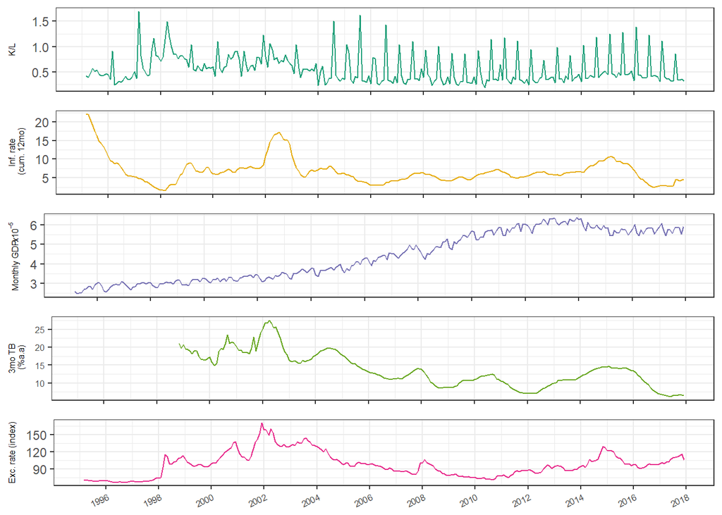

## Treating for seasonality and structural breaks

Obs: I am not treating the GDP for now.

### 1. Capital-Labor Ratio

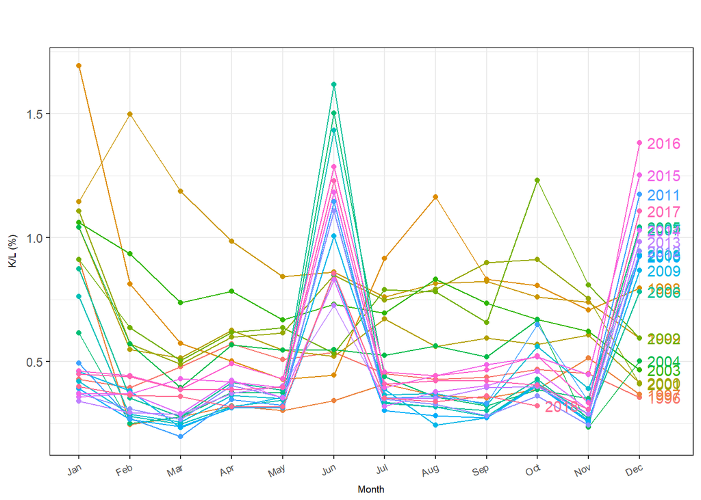

```r
# Calculates the structural breaks
bp_ts <- breakpoints(capital_trabalho ~ 1)
ci_ts <- confint(bp_ts)

# Monthplot aggregates days and months and takes averages
meses <- ggmonthplot(capital_trabalho) +
  theme_bw() +
  #scale_y_continuous(name = "Capital-Labor Ratio (% - average)") +
  scale_y_continuous(name = "K/L") +
  labs(title = "", x = "Month", subtitle = "")+
  theme(axis.title = element_text(size=7), axis.text.x = element_text(angle=25, hjust = 1, size = 7))
  #labs(title = "Média diária e mensal da razão capital-trabalho", x = "Mês", subtitle = "Nenhuma transformação")
  #labs(title = "Daily and monthly averages of Capital-Labor ratio", x = "Month", subtitle = "No data transformation")

# Seasonplot has the averages for month, each line represents a year
season <- ggseasonplot(capital_trabalho, year.labels = TRUE) +
  geom_point() +
  theme_bw() +
  scale_y_continuous(name = "K/L (%)") +
  labs(title = "", x = "Month", subtitle = "")+
  theme(axis.title = element_text(size=7), axis.text.x = element_text(angle=25, hjust = 1, size = 7))
  #scale_y_continuous(name = "Capital-Labor Ratio (% - average)") +
  #labs(title = "Monthly averages of Capital-Labor ratio", x = "Months", subtitle = "No data transformation")

#pdf(file = "D:\\Onedrive - Aisha\\OneDrive\\Documentos\\Mestrado Economia\\Dissertação\\Texto final\\Figuras\\Descritivas\\Fig-Season_CT.pdf", width = 6, height = 3)
season
```

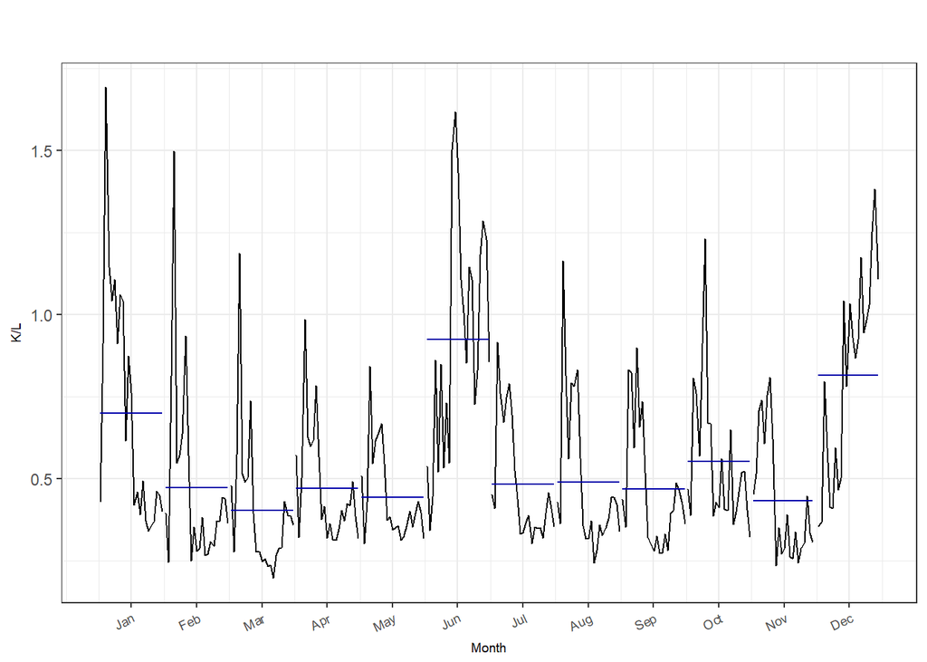

```r
#dev.off()

#pdf(file = "D:\\Onedrive - Aisha\\OneDrive\\Documentos\\Mestrado Economia\\Dissertação\\Texto final\\Figuras\\Descritivas\\Fig-Month_CT.pdf", width = 6, height = 3)
meses
```

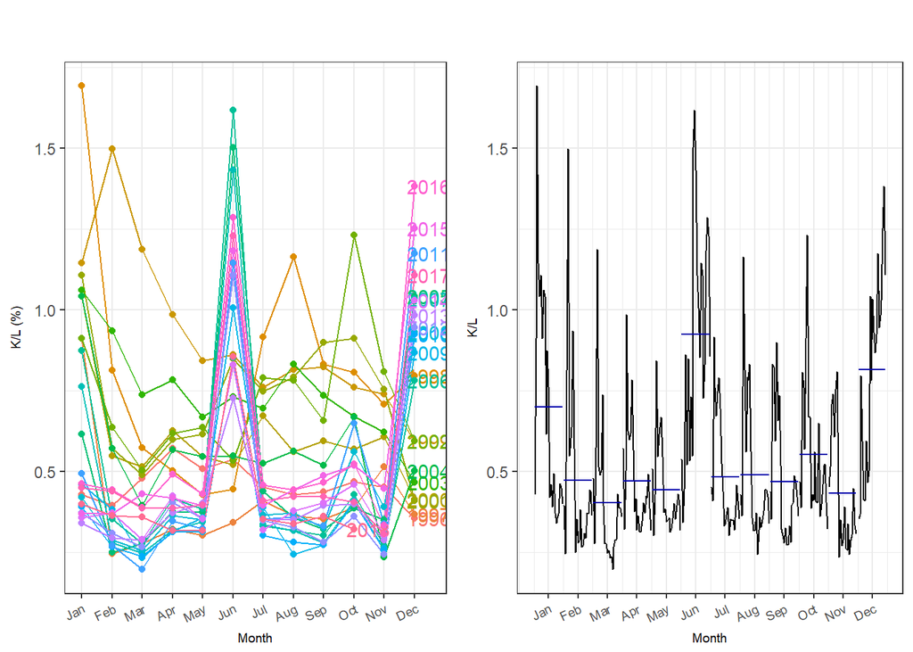

```r
#dev.off()

#pdf(file = "D:\\Onedrive - Aisha\\OneDrive\\Documentos\\Mestrado Economia\\Dissertação\\Texto final\\Figuras\\Descritivas\\Fig-Season_CT.pdf", width = 12, height = 3)
grid.arrange(season,meses, ncol=2, nrow=1)
```

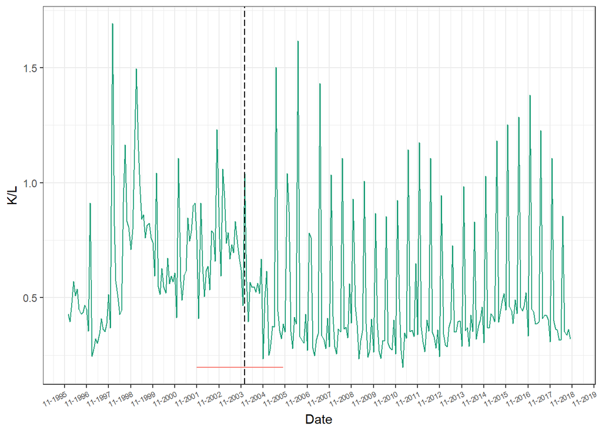

```r
#dev.off()

Data <- seq(as.Date("1996-01-01"), length = length(capital_trabalho), by = "1 month")
df1 <- melt(data.frame(Data,capital_trabalho), id.vars = "Data")
names(df1) <- c("Data", "Variavel", "Valor")

# Graph with structural break (dashed) and CI (red)
p1 <- ggplot(df1[which(df1$Variavel == "capital_trabalho"),], aes(Data, Valor, colour = Variavel)) +
        geom_line(alpha = 1, show.legend=F, colour = cores[1])+
        scale_y_continuous(name = "K/L") +
        #scale_y_continuous(name="Capital-Labor ratio") +
        scale_x_date(date_breaks = "12 months", name = "Date", labels = date_format("%m-%Y"))+
        geom_vline(xintercept = Data[bp_ts$breakpoints], linetype="longdash")+
        geom_segment(aes(x = Data[ci_ts$confint[1]], y = min(capital_trabalho), xend = Data[ci_ts$confint[3]], yend = min(capital_trabalho)))+
        theme_bw()
p1 <- p1 + theme(axis.text.x = element_text(angle=25, hjust = 1, size = 6), legend.position = "none")

#pdf(file = "D:\\Onedrive - Aisha\\OneDrive\\Documentos\\Mestrado Economia\\Dissertação\\Texto final\\Figuras\\Descritivas\\Fig-Quebra_CT.pdf", width = 6, height = 3)
p1
```

```r
#dev.off()

# We divide the series in pieces (accordingly to the structural break)
capital_trabalho_a <- capital_trabalho[1:bp_ts$breakpoints]
capital_trabalho_b <- capital_trabalho[(bp_ts$breakpoints+1):length(capital_trabalho)]
capital_trabalho_a <- ts(capital_trabalho_a,  start = c(1996, 01, 01), frequency = 12)
capital_trabalho_b <- ts(capital_trabalho_b,  start = c(2004, 02, 01), frequency = 12)

m <- seas(x = capital_trabalho_a, transform.function = "none", regression.aictest = NULL)
#m <- seas(x = capital_trabalho_a, regression.aictest = NULL)

## First diagnostics is using qs() function to check for seasonality after the adjustment
qs(m)
```

```
##                    qs   p-val
## qsori        34.12733 0.00000
## qsorievadj   91.53477 0.00000
## qsrsd         0.00000 1.00000
## qssadj        0.00000 1.00000
## qssadjevadj   0.00000 1.00000
## qsirr         0.00078 0.99961
## qsirrevadj    0.00000 1.00000
## qssori       33.13775 0.00000
## qssorievadj  85.86391 0.00000
## qssrsd        0.00000 1.00000
## qsssadj       0.00000 1.00000
## qsssadjevadj  0.00000 1.00000
## qssirr        0.05069 0.97497
## qssirrevadj   0.00000 1.00000
```

```r
# Click here to see the how the qs statistics is calculated: https://stats.stackexchange.com/questions/148573/the-results-and-specifics-from-the-qs-function-in-r
# The first 7 results are related to the whole series, the last 7 comprehends only the last 8 years
# qsori is the original series
# qsorievadj is the original series corrected for extreme values
# qsrsd is the residual's series of the ARIMA model
# qssadj is the series with seasonal adjustment
# qssadjevadj is the series with seasonal adjustment corrected for extreme values
# qsirr is the series of the irregular component
# qsirrevadj is the series of the irregular component corrected for extreme values
# by the output, we can conclude that there is no evidence of seasonal components in the adjusted series, the residuals and the irregular component, even when we look just the last 8 years.

# Next step is to diagnose the pre-adjust and the ARIMA model
summary(m)
```

```
##
## Call:
## seas(x = capital_trabalho_a, transform.function = "none", regression.aictest = NULL)
##
## Coefficients:
##                   Estimate Std. Error z value Pr(>|z|)
## AO1996.Jan        -0.35561    0.10377  -3.427 0.000611 ***
## AO1998.Jan         0.67046    0.08634   7.766 8.12e-15 ***
## LS1998.Jul         0.28775    0.05339   5.390 7.06e-08 ***
## AO1998.Aug         0.29547    0.08564   3.450 0.000561 ***
## AO1999.Feb         0.68086    0.09704   7.016 2.28e-12 ***
## AO1999.Mar         0.37531    0.09644   3.892 9.96e-05 ***
## AO2002.Oct         0.49217    0.08564   5.747 9.10e-09 ***
## AR-Nonseasonal-01  0.64477    0.07100   9.081  < 2e-16 ***
## MA-Seasonal-12     0.99965    0.08975  11.138  < 2e-16 ***
## ---
## Signif. codes:  0 '***' 0.001 '**' 0.01 '*' 0.05 '.' 0.1 ' ' 1
##
## SEATS adj.  ARIMA: (1 0 0)(0 1 1)  Obs.: 97  Transform: none
## AICc: -109.8, BIC: -88.36  QS (no seasonality in final):    0
## Box-Ljung (no autocorr.): 20.02   Shapiro (normality): 0.9765 .
```

```r
# We have an level-shift outlier in July, 1998 (Asian crisis?)
# We also have additive outliers in Jan96, Jan98, Aug98, Feb99, Mar99, Oct02
# The estimated model is an ARIMA (1 0 0)(0 1 1) with the non-seasonal AR significative and the MA seasonal significative.
capital_trabalho_2a <- final(m)

m <- seas(x = capital_trabalho_b, transform.function = "none", regression.aictest = NULL)

#m <- seas(x = capital_trabalho_b, regression.aictest = NULL) # se tomar o log, fica melhor
qs(m)
```

```
##                     qs   p-val
## qsori        261.00180 0.00000
## qsorievadj   303.81326 0.00000
## qsrsd          0.00058 0.99971
## qssadj         2.87669 0.23732
## qssadjevadj    0.00000 1.00000
## qsirr          2.29770 0.31700
## qsirrevadj     0.00000 1.00000
## qssori       133.23059 0.00000
## qssorievadj  154.74583 0.00000
## qssrsd         0.00000 1.00000
## qsssadj        5.11059 0.07767
## qsssadjevadj   0.00000 1.00000
## qssirr         6.80927 0.03322
## qssirrevadj    0.00000 1.00000
```

```r
summary(m)
```

```
##
## Call:
## seas(x = capital_trabalho_b, transform.function = "none", regression.aictest = NULL)
##
## Coefficients:
##                   Estimate Std. Error z value Pr(>|z|)
## AO2004.Jun        -0.75210    0.07891  -9.531  < 2e-16 ***
## LS2004.Nov        -0.33282    0.04112  -8.094 5.76e-16 ***
## AO2004.Dec        -0.39750    0.05547  -7.166 7.75e-13 ***
## LS2005.Mar         0.15270    0.03684   4.144 3.41e-05 ***
## AO2005.Jun         0.37346    0.07091   5.267 1.39e-07 ***
## AO2006.Jun         0.51096    0.06158   8.298  < 2e-16 ***
## AO2006.Dec        -0.22561    0.04209  -5.360 8.31e-08 ***
## AO2007.Jun         0.35736    0.05093   7.017 2.27e-12 ***
## AO2008.Jan        -0.19683    0.04137  -4.758 1.95e-06 ***
## AO2010.Jun        -0.19718    0.04142  -4.761 1.93e-06 ***
## AO2011.Oct         0.23023    0.04150   5.548 2.89e-08 ***
## AO2011.Dec         0.22003    0.04149   5.303 1.14e-07 ***
## AO2013.Jun        -0.40308    0.04398  -9.166  < 2e-16 ***
## AO2014.Jun        -0.31420    0.04395  -7.149 8.77e-13 ***
## AO2016.Dec         0.21112    0.04203   5.023 5.09e-07 ***
## AO2018.Jun        -0.30450    0.05112  -5.956 2.58e-09 ***
## MA-Nonseasonal-01  0.72602    0.05396  13.455  < 2e-16 ***
## MA-Seasonal-12     0.32349    0.07408   4.366 1.26e-05 ***
## ---
## Signif. codes:  0 '***' 0.001 '**' 0.01 '*' 0.05 '.' 0.1 ' ' 1
##
## SEATS adj.  ARIMA: (0 1 1)(0 1 1)  Obs.: 177  Transform: none
## AICc: -442.3, BIC: -388.6  QS (no seasonality in final):2.877
## Box-Ljung (no autocorr.): 12.62   Shapiro (normality): 0.9604 ***
```